← Voltar ao Portal

[figure not shown]

Programa 432

# Síntese Avaliativa do Desempenho dos Programas do PPA Bahia 2024–2027

# **1 - Desempenho Global do Programa**

Este documento apresenta uma Síntese Avaliativa do Desempenho do Programa do Plano Plurianual - PPA 2024- 2027, trazendo uma visão estratégica dos seus resultados, de forma sintética, transparente e colaborativa. Serão levados em consideração o Indicador Sintético de Desempenho do Programa (ISDP), a evolução dos Indicadores de Programa, a eficácia das metas dos Indicadores de Compromisso, o desempenho da execução orçamentária-financeira e da execução física das Ações orçamentárias. O ISDP é uma síntese dessas quatro dimensões, destacando o desempenho do programa em relação aos resultados obtidos e aos esforços despendidos.  
Adicionalmente, são apresentados os principais resultados alcançados, evidenciando os avanços e conformidades dos cinco programas com melhores resultados, além das oportunidades de melhoria dos cinco, com menores resultados. Enquanto neste documento a análise abrange o programa e seus componentes de maneira sintética, nos demais relatórios, a análise detalhada evidencia o comportamento dos componentes do PPA por programas e por órgãos (https://www.ba.gov.br/seplan/monitoramento-e-avaliacao/avaliacao-do-ppa). Além desta Síntese, o [Painel BI - Boletim de Avanços e Oportunidades de Melhoria](https://app.powerbi.com/view?r=eyJrIjoiN2Q0ODliNDItZDFjZi00MGM1LTliNGEtODVmZDAwZTQ1OGEyIiwidCI6IjRjZDgzNWY0LTU0NDAtNDA4Zi05M2EzLTk3NWZjMTdjMzg0YSIsImMiOjR9) oferece informações organizadas em uma perspectiva estratégica do desempenho consolidado dos programas, detalhando, no entanto, cada componente avaliado. A análise nesta seção engloba o programa e seus componentes conforme segue:

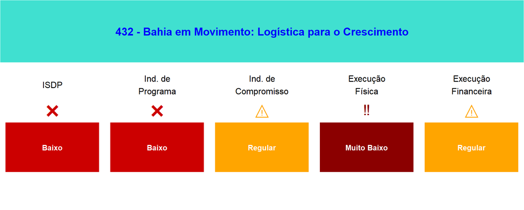

# **2 - Avanços e Conformidades no Programa**

**Indicadores de Programa:** No programa 432 - Bahia em Movimento: Logística para o Crescimento, 50% dos indicadores mostraram evolução positiva. O destaque vai para o indicador 2221, que avalia a proporção de extensão das rodovias com boa ou ótima qualidade, com um crescimento de 7,04%. Esse resultado pode ser explicado pelo aporte de recursos orçamentários que facilitaram a execução de ações, tais como investimentos em recuperação e pavimentação de rodovias, além de contratos focados em desempenho (Contratos de Restauração e Manutenção - CREMA).  
**Indicadores de Compromisso:** No programa 432 - Bahia em Movimento: Logística para o Crescimento, 37,5% dos indicadores foram classificados como de desempenho bom ou ótimo. O indicador ‘3 - Percentual de planos e estudos realizados’ se destacou com 126,24%, resultado da otimização das estratégias decorrente da chegada de novos funcionários à SUPLOG, que aprimoraram os processos. Por outro lado, o indicador ‘1 - Número de terminais aeroviários, rodoviários e hidroviários construídos’ alcançou 75%, em função de atrasos na entrega de serviços que afetaram a conclusão do Aeroporto de Senhor do Bonfim.  
**Ações Orçamentárias:** O Programa 432 - Bahia em Movimento: Logística para o Crescimento registrou 70% de ações com bom ou ótimo desempenho financeiro e 19,2% na execução física. A Ação 3035 - Pavimentação de Rodovia na BA.262, Almadina - Floresta Azul obteve classificações ótimas em ambas as dimensões, enquanto a Ação 2856 - Licenciamento Ambiental para Serviço e Obra de Infraestrutura de Transportes alcançou classificações boas.

# **3 - Oportunidade de Melhoria no Programa**

**Indicadores de Programa:** No programa 432 - Bahia em Movimento: Logística para o Crescimento, 50% dos indicadores apresentaram evolução negativa, com o indicador 02220 - Evolução da movimentação de trens em transporte de carga sofrendo uma diminuição extrema.  
**Indicadores de Compromisso:** No Programa 432, Bahia em Movimento: Logística para o Crescimento, 25% dos indicadores apresentaram desempenho baixo ou muito baixo, e 12,5% foram indeterminados. O indicador ‘2 - Quantidade de quilômetros de rodovias implantadas e pavimentadas’ alcançou 225,69%, reflexo da imutabilidade da malha rodoviária estadual, que permanece integralmente atendida. Isso comprometeu a análise evolutiva da meta, evidenciando a necessidade de revisão do indicador. Além disso, o indicador ‘4 - Proporção de pontos críticos suprimidos em estradas vicinais’ registrou desempenho de 0%, pois o novo programa para supressão de pontos críticos encontra-se em fase de diagnóstico, com previsão de início dos trabalhos para 2026.  
**Ações Orçamentárias:** No entanto, no Programa 432 - Bahia em Movimento: Logística para o Crescimento, 26% das ações foram classificadas com desempenho baixo ou muito baixo na execução financeira, enquanto 79,9% na execução física apresentaram a mesma situação. Exemplos incluem a ação 3357 - Pavimentação de Rodovia na BA-959 e a ação 7024 - Aprimoramento do Sistema de Planejamento Rodoviário, que tiveram desempenhos classificados como “Muito Baixo”.

Desenvolvido por: DAP – Diretoria de Avaliação de Políticas Públicas